# Дисперсионный анализ, часть 2

## Многофакторный дисперсионный анализ

- Модель многофакторного дисперсионного анализа
- Взаимодействие факторов
- Несбалансированные данные, типы сумм квадратов
- Многофакторный дисперсионный анализ в R
- Дисперсионный анализ в матричном виде

### Вы сможете

- Проводить многофакторный дисперсионный анализ и интерпретироваот его результаты с учетом взаимодействия факторов

## Модель многофакторного дисперсионного анализа

## Линейные модели с разным числом дискретных предикторов

- Два фактора A и B, двухфакторное взаимодействие

\(y _{ijk} = \mu + \alpha _i + \beta _j + (\alpha \beta) _{ij} + \epsilon _{ijk}\)

- Три фактора A, B и C, двухфакторные взаимодействия, трехфакторное взаимодействия

\(y _{ijkl} = \mu + \alpha _i + \beta _j + \gamma _k + (\alpha \beta) _{ij} + (\alpha \gamma) _{ik} + (\beta \gamma) _{jk} + (\alpha \beta \gamma) _{ijk} + \epsilon _{ijkl}\)

## Взаимодействие дискретных предикторов

## Взаимодействие дискретных предикторов

Взаимодействие факторов - когда эффект фактора B разный в зависимости от уровней фактора A и наоборот

На каких рисунках есть взаимодействие факторов?

- b, c - нет взаимодействия (эффект фактора B одинаковый для групп по фактору A, линии для разных групп по фактору B на графиках расположены параллельно)
- a, d - есть взаимодействие (эффект фактора B разный для групп по фактору A, на графиках линии для разных групп по фактору B расположены под наклоном).

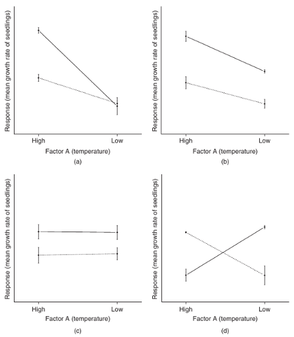

Рисунок из Logan, 2010, fig.12.2

## Влияют ли главные эффекты и взаимодействие?

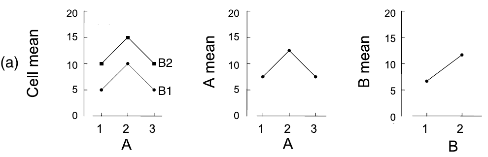

Рисунок из Quinn, Keough, 2002, fig.9.3

## Влияют ли главные эффекты и взаимодействие?

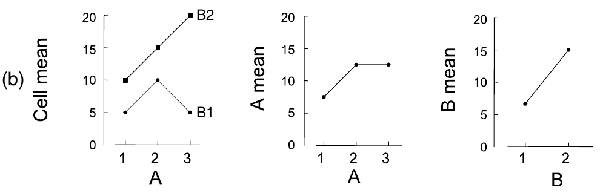

- взаимодействие достоверно и мешает интерпретировать влияние факторов отдельно:
  - для В2 зависимая переменная возрастает с изменением уровня А
  - для В1 зависимая переменная возрастает только на А2, но не различается на А1 и А3
- если смотреть на главные эффекты, можно сделать неправильные выводы:
  - фактор А влияет, группы А2 и А3 не отличаются
  - фактор В влияет, в группе В2 зависимая переменная больше, чем в В1

Рисунок из Quinn, Keough, 2002, fig.9.3

## Влияют ли главные эффекты и взаимодействие?

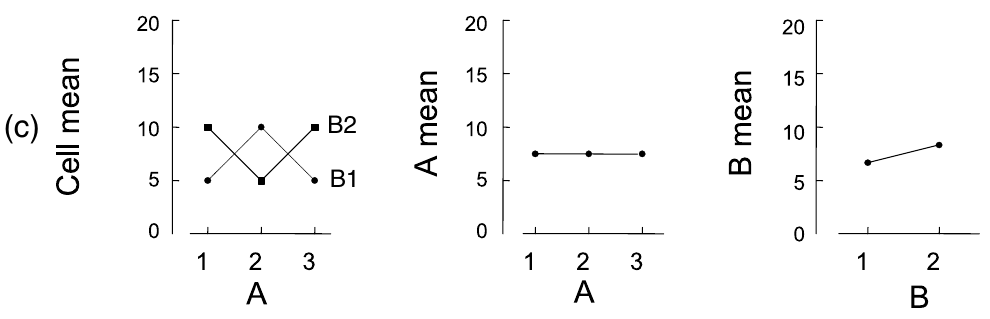

- взаимодействие достоверно и мешает интерпретировать влияние факторов отдельно:
  - А1В2, А3В2 и А2В1 не различаются, значение зависимой переменной в этих группах выше, чем в остальных
  - А1В1, А3В1 и А2В2 не различаются
- если смотреть на главные эффекты, можно сделать неправильные выводы:
  - факторы А и В не влияют

Рисунок из Quinn, Keough, 2002, fig.9.3

## Взаимодействие факторов может маскировать главные эффекты

- Если есть значимое взаимодействие
- главные эффекты обсуждать не имеет смысла
- пост хок тесты проводятся только для ваимодействия

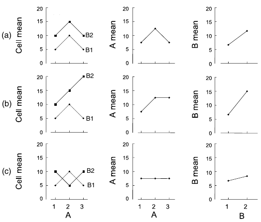

Рисунок из Quinn, Keough, 2002, fig.9.3

## Несбалансированные данные, типы сумм квадратов

## Несбалансированные данные - когда численности в группах по факторам различаются

Например так,

|  | A1 | A2 | A3 |
| --- | --- | --- | --- |
| B1 | 5 | 5 | 5 |
| B2 | 5 | 4 | 5 |

или так,

|  | A1 | A2 | A3 |
| --- | --- | --- | --- |
| B1 | 3 | 8 | 4 |
| B2 | 4 | 7 | 4 |

## Проблемы несбалансированных дизайнов

- Оценки средних в разных группах с разным уровнем точности (Underwood 1997)
- ANOVA менее устойчив к отклонениям от условий применимости (особенно от гомогенности дисперсий) при разных размерах групп (Quinn Keough 2002, section 8.3)
- Проблемы с рассчетом мощности. Если \(\sigma _{\epsilon}^2 > 0\) и размеры выборок разные, то \(MS _{factor} \over MS _{residuals}\) не следует F-распределению (Searle et al. 1992).
- Cтарайтесь *планировать* группы равной численности!
- Но если не получилось - не страшно:
  - Для фикс. эффектов неравные размеры - проблема только если значения доверительной вероятности *p* близки к выбранному критическому уровню значимости \(\alpha\)

## Если несбалансированные данные, выберите правильный тип сумм квадратов

- SSe и SSab также как в сбалансированных
- SSa, SSb - три способа расчета
- Для сбалансированных дизайнов - результаты одинаковы
- Для несбалансированных дизайнов рекомендуют **суммы квадратов III типа** если есть взаимодействие факторов (Maxwell & Delaney 1990, Milliken, Johnson 1984, Searle 1993, Yandell 1997)

## Типы сумм квадратов в дисперсионном анализе

| Типы сумм квадратов | I тип | II тип | III тип |
| --- | --- | --- | --- |
| Название | Последовательная | Без учета взаимодействий высоких порядков | Иерархическая |
| SS | SS(A), SS(B ∣ A) SS(AB ∣ B, A) | SS(A ∣ B) SS(B ∣ A) SS(AB ∣ B, A) | SS(A ∣ B, AB) SS(B ∣ A, AB) SS(AB ∣ B, A) |
| Величина эффекта зависит от выборки в группе | Да | Да | Нет |
| Результат зависит от порядка включения факторов в модель | Да | Нет | Нет |
| Команда R | `aov()` | `Anova()` (пакет `car`) | `Anova()` (пакет `car`) |

## Многофакторный дисперсионный анализ в R

## Пример: Удобрение и беспозвоночные

Влияет ли добавление азотных и фосфорных удобрений на беспозвоночных?

Небольшие искуственные субстраты экспонировали в течение разного времени в верхней части сублиторали (Hall et al., 2000).

Факторы:

- срок экспозиции (2, 4 и 6 месяцев)
- удобрения (добавляли или нет)

Планировали сделать 5 повторностей для каждого сочетания факторов

Зависимая переменная:

- Число видов

Данные из Quinn, Keough, 2002

## Знакомимся с данными

```r
dat <- read.csv(file = "data/hall.csv")
str(dat)
```

```
## 'data.frame':    29 obs. of  3 variables:
##  $ TREAT   : Factor w/ 2 levels "control","nutrient": 1 1 1 1 1 1 1 1 1 1 ...
##  $ TIME    : int  2 2 2 2 2 4 4 4 4 4 ...
##  $ RICHNESS: int  5 7 5 7 5 20 18 20 18 17 ...
```

```r
# Для удобства названия переменных маленькими буквами
colnames(dat) <- tolower(colnames(dat))
# Время делаем фактором
dat$time <- factor(dat$time)
levels(dat$time)
```

```
## [1] "2" "4" "6"
```

## Пропущенные значения

```r
sum(is.na(dat))
```

```
## [1] 0
```

```r
sapply(dat, function(x) sum(is.na(x)))
```

```
##    treat     time richness
##        0        0        0
```

- Нет пропущенных значений

## Объемы выборок в группах

```r
table(dat$time, dat$treat)
```

```
##
##     control nutrient
##   2       5        5
##   4       5        5
##   6       4        5
```

- Группы разного размера. Выбираем 3 тип сумм квадратов

## Посмотрим на боксплот

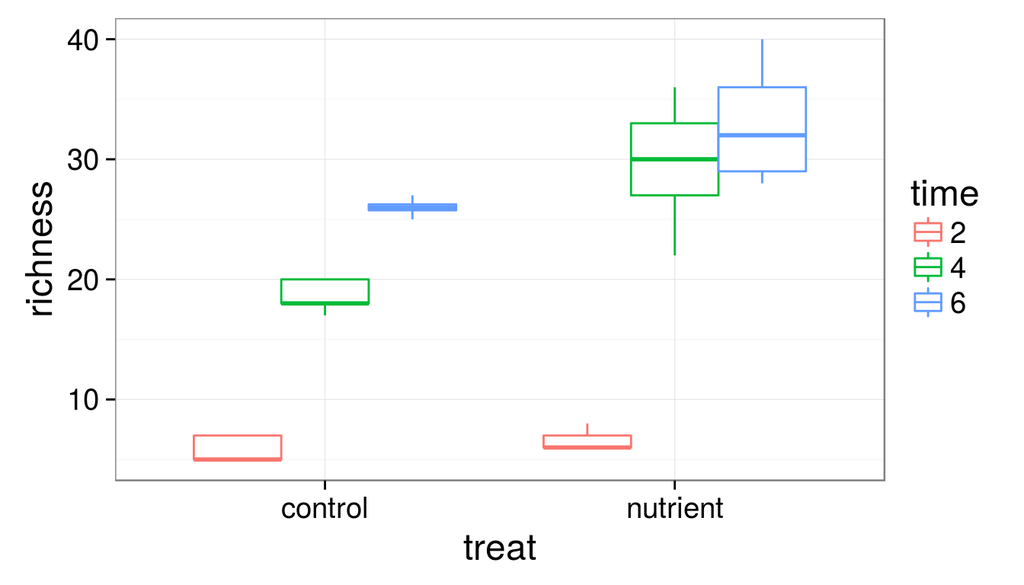

```r
library(ggplot2)
theme_set(theme_bw(base_size = 18) + theme(legend.key = element_blank()))
gg_rich <- ggplot(data = dat, aes(x = treat, y = richness, colour = time)) +
    geom_boxplot()
gg_rich
```

## Преобразовываем данные

На боксплоте видна гетерогенность дисперсий. И это неспроста!

Зависимая переменная `richness` – это счетная величина. Она подчиняется распределению Пуассона (и чем больше ее среднее значение, тем больше дисперсия).

Правильно было бы воспользоваться обобщенными линейными моделями с Пуассоновским распределением ошибок вместо нормального. Но пока что мы попробуем преобразовать зависимую переменную, чтобы ее распределение стало больше походить на нормальное. Это может помочь, а может и нет.

```r
dat$log_rich <- log10(dat$richness + 1)
```

## Линейная модель

Внимание: при использовании III типа сумм квадратов, нужно **обязательно указывать тип контрастов для факторов** (`contrasts=list(фактор_1 = contr.sum, фактор_2=contr.sum)`).

```r
fit <- lm(log_rich ~ treat * time, data = dat,
    contrasts = list(treat = contr.sum, time = contr.sum))
```

## Задание: Проверьте условия применимости дисперсионного анализа

- Есть ли гомогенность дисперсий?
- Не видно ли трендов в остатках?
- Нормальное ли у остатков распределение?

## Решение: 1. Проверяем условия применимости

- Есть ли гомогенность дисперсий?
- Не видно ли трендов в остатках?

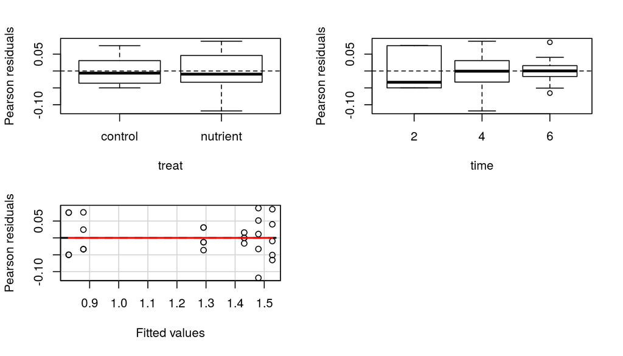

```r
library(car)
residualPlots(fit)
```

- Все хорошо

## Решение: 2. Проверяем условия применимости

- Нормальное ли у остатков распределение?

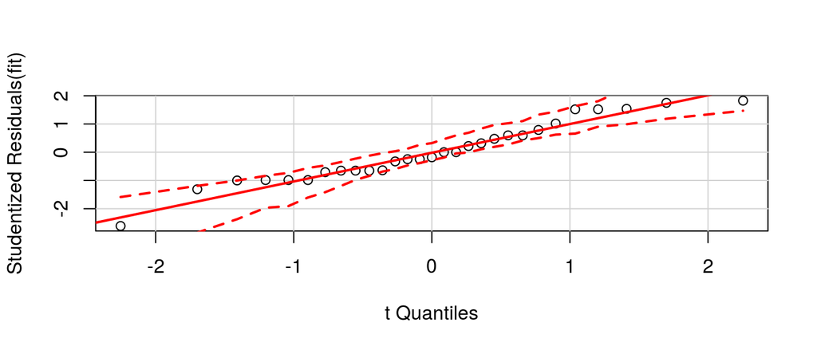

```r
qqPlot(fit)
```

- Все хорошо

## Результаты дисперсионного анализа

```r
Anova(fit, type = 3)
```

```
## Anova Table (Type III tests)
##
## Response: log_rich
##             Sum Sq Df  F value   Pr(>F)
## (Intercept)   44.2  1 13776.11  < 2e-16 ***
## treat          0.1  1    28.04 0.000022 ***
## time           2.2  2   344.75  < 2e-16 ***
## treat:time     0.0  2     3.84    0.036 *
## Residuals      0.1 23
## ---
## Signif. codes:
##   0 '***' 0.001 '**' 0.01 '*' 0.05 '.' 0.1  ' ' 1
```

- Поскольку взаимодействие достоверно, факторы отдельно можно не тестировать. Проведем пост хок тест по взаимодействию, чтобы выяснить, какие именно группы различаются

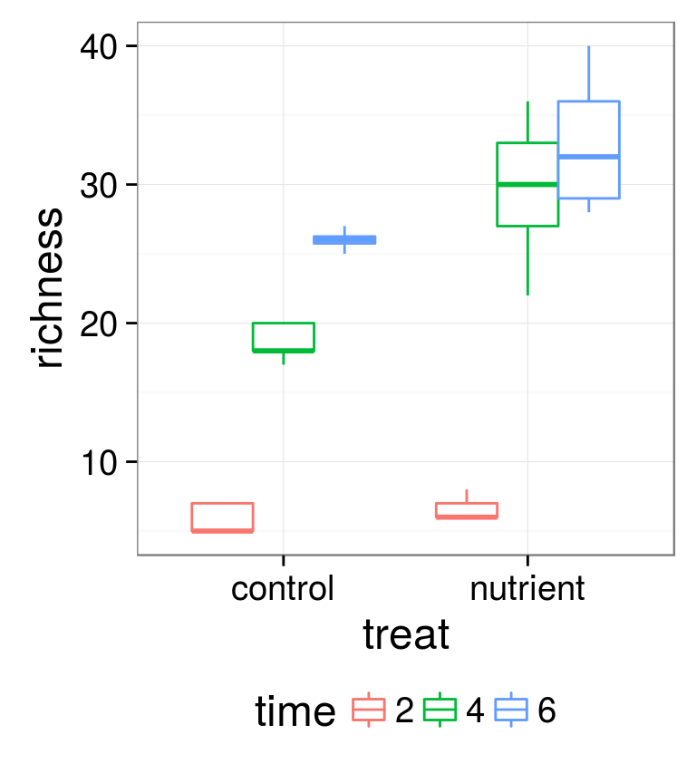

## Пост хок тест

```r
# 1. создаем переменную-взаимодействие
dat$treat_time <- interaction(dat$treat, dat$time)

# 2. подбираем модель без intercept
fit_inter <- lm(log_rich ~ treat_time - 1, data = dat)

# 3. делаем пост хок тест
library(multcomp)
dat_tukey <- glht(fit_inter, linfct = mcp(treat_time = "Tukey"))
summary(dat_tukey)
```

## Смотрим на результаты пост хок теста

```
##
##   Simultaneous Tests for General Linear Hypotheses
##
## Multiple Comparisons of Means: Tukey Contrasts
##
##
## Fit: lm(formula = log_rich ~ treat_time - 1, data = dat)
##
## Linear Hypotheses:
##                              Estimate Std. Error t value Pr(>|t|)
## nutrient.2 - control.2 == 0    0.0504     0.0358    1.41    0.723
## control.4 - control.2 == 0     0.4633     0.0358   12.93   <0.001 ***
## nutrient.4 - control.2 == 0    0.6519     0.0358   18.19   <0.001 ***
## control.6 - control.2 == 0     0.6031     0.0380   15.86   <0.001 ***
## nutrient.6 - control.2 == 0    0.6997     0.0358   19.52   <0.001 ***
## control.4 - nutrient.2 == 0    0.4129     0.0358   11.52   <0.001 ***
## nutrient.4 - nutrient.2 == 0   0.6015     0.0358   16.78   <0.001 ***
## control.6 - nutrient.2 == 0    0.5527     0.0380   14.54   <0.001 ***
## nutrient.6 - nutrient.2 == 0   0.6493     0.0358   18.11   <0.001 ***
## nutrient.4 - control.4 == 0    0.1885     0.0358    5.26   <0.001 ***
## control.6 - control.4 == 0     0.1398     0.0380    3.68    0.014 *
## nutrient.6 - control.4 == 0    0.2364     0.0358    6.59   <0.001 ***
## control.6 - nutrient.4 == 0   -0.0488     0.0380   -1.28    0.791
## nutrient.6 - nutrient.4 == 0   0.0478     0.0358    1.33    0.763
## nutrient.6 - control.6 == 0    0.0966     0.0380    2.54    0.153
## ---
## Signif. codes:  0 '***' 0.001 '**' 0.01 '*' 0.05 '.' 0.1 ' ' 1
## (Adjusted p values reported -- single-step method)
```

## Данные для графиков

```r
library(dplyr)
dat_summary <- dat %>%
  group_by(treat, time) %>%
  summarise(
    .mean = mean(richness),
    .sd = sd(richness),
    .n = sum(!is.na(richness)),
    .se = .sd/sqrt(.n),
    lwr = .mean - qnorm(0.975) * .se,
    upr = .mean + qnorm(0.975) * .se)
dat_summary
```

```
## Source: local data frame [6 x 8]
## Groups: treat [?]
##
##      treat   time .mean   .sd    .n   .se   lwr   upr
##     (fctr) (fctr) (dbl) (dbl) (int) (dbl) (dbl) (dbl)
## 1  control      2   5.8 1.095     5 0.490  4.84  6.76
## 2  control      4  18.6 1.342     5 0.600 17.42 19.78
## 3  control      6  26.0 0.816     4 0.408 25.20 26.80
## 4 nutrient      2   6.6 0.894     5 0.400  5.82  7.38
## 5 nutrient      4  29.6 5.413     5 2.421 24.86 34.34
## 6 nutrient      6  33.0 5.000     5 2.236 28.62 37.38
```

## Графики для результатов: Столбчатый график

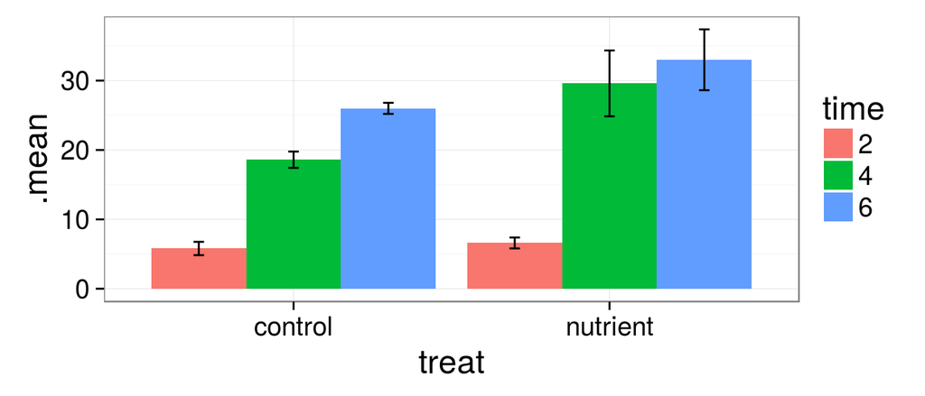

```r
pos <- position_dodge(width = 0.9)
gg_barp <- ggplot(data = dat_summary, aes(x = treat, y = .mean,
    ymin = lwr, ymax = upr, fill = time)) + geom_bar(stat = "identity",
    position = pos) + geom_errorbar(width = 0.1, position = pos)
gg_barp
```

## Графики для результатов: Линии с точками

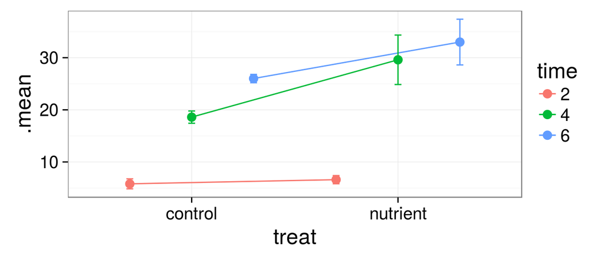

```r
gg_linep <- ggplot(data = dat_summary, aes(x = treat, y = .mean,
    ymin = lwr, ymax = upr, colour = time)) + geom_point(size = 3,
    position = pos) + geom_line(aes(group = time), position = pos) +
    geom_errorbar(width = 0.1, position = pos)
gg_linep
```

## Какой график лучше выбрать?

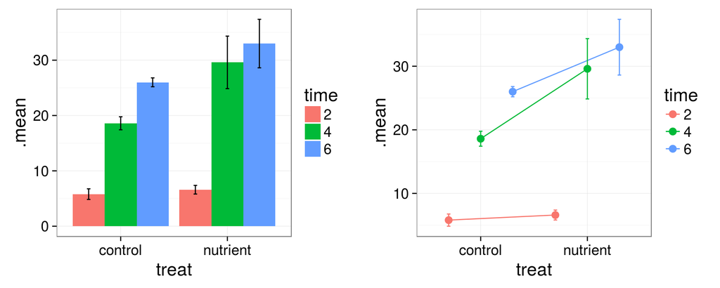

```r
library(gridExtra)
grid.arrange(gg_barp, gg_linep, ncol = 2)
```

- Должен быть максимум данных в минимуме чернил (Tufte, 1983)

## Приводим понравившийся график в приличный вид

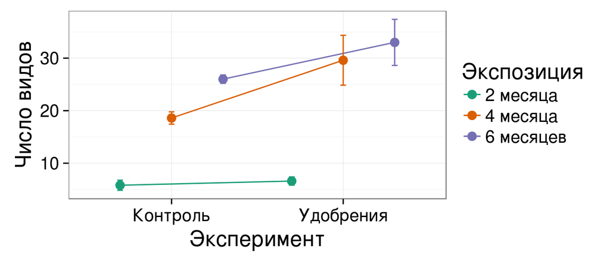

```r
gg_final <- gg_linep + labs(x = "Эксперимент", y = "Число видов") +
    scale_x_discrete(labels = c("Контроль", "Удобрения")) +
    scale_colour_brewer(name = "Экспозиция", palette = "Dark2",
        labels = c("2 месяца", "4 месяца", "6 месяцев"))
gg_final
```

## Регрессия в матричном виде

## Регрессия в матричном виде

Уравнение простой линейной регрессии:

\[y _{i} = \beta _0 + \beta _1 x _i + \epsilon _{i}\]

Здесь \(i = 1, ..., n\), т.е. порядковый номер наблюдения

Если расписать эту формулу, получится по отдельному уравнению для каждого из наблюдений:

\[\begin{align*} y &_{1} = \beta _0 + \beta _1 x _1 + \epsilon _{1} \\ y &_{2} = \beta _0 + \beta _1 x _2 + \epsilon _{2} \\ &\vdots \\ y &_{n} = \beta _0 + \beta _1 x _n + \epsilon _{n} \end{align*}\]

Эту систему уравнений

\[\begin{align*} y &_{1} = \beta _0 + \beta _1 x _1 + \epsilon _{1} \\ y &_{2} = \beta _0 + \beta _1 x _2 + \epsilon _{2} \\ &\vdots \\ y &_{n} = \beta _0 + \beta _1 x _n + \epsilon _{n} \end{align*}\]

можно переписать в виде матриц:

\[\left[\begin{array}{c} y_1 \\ y_2 \\ \vdots \\ y_n \end{array}\right] = \left[\begin{array}{cc} 1 & x_1 \\ 1 & x_2 \\ \vdots & \\ 1 & x_n \end{array}\right] \cdot \left[\begin{array}{c} \beta _0 \\ \beta _1 \end{array}\right] + \left[\begin{array}{c} \epsilon _1 \\ \epsilon _2 \\ \vdots \\ \epsilon _n \end{array}\right] \]

Для такой длинной формы записи матриц

\[\left[\begin{array}{c} y_1 \\ y_2 \\ \vdots \\ y_n \end{array}\right] = \left[\begin{array}{cc} 1 & x_1 \\ 1 & x_2 \\ \vdots & \\ 1 & x_n \end{array}\right] \cdot \left[\begin{array}{c} \beta _0 \\ \beta _1 \end{array}\right] + \left[\begin{array}{c} \epsilon _1 \\ \epsilon _2 \\ \vdots \\ \epsilon _n \end{array}\right] \]

есть сокращенная форма записи:

\[Y = X \beta + \epsilon\]

## Задание:

В примере с влиянием удобрений на макрофауну:

- Какова будет размерность матрицы независимых переменных (сколько в ней строк и столбцов)?
- Сколько значений будет в матрице коэффициентов?
- Какова размерность матрицы ошибок?

### Подсказка:

Для модели с одним предиктором матрицы будут выглядеть так

\[\left[\begin{array}{c} y_1 \\ y_2 \\ \vdots \\ y_n \end{array}\right] = \left[\begin{array}{cc} 1 & x_1 \\ 1 & x_2 \\ \vdots & \\ 1 & x_n \end{array}\right] \cdot \left[\begin{array}{c} \beta _0 \\ \beta _1 \end{array}\right] + \left[\begin{array}{c} \epsilon _1 \\ \epsilon _2 \\ \vdots \\ \epsilon _n \end{array}\right] \]

А для модели с несколькими предикторами?

## Как закодировать дискретные предикторы?

У нас два дискретных фактора: 3 времени экспозиции и 2 тритмента. Использована модель эффектов (contr.sum), поэтому переменные-болванки будут закодированы при помощи -1, 0 и 1, так, чтобы сумма кодов для возможных состояний одной переменной была равна нулю.

Вот так будут закодированы уровни фактора "удобрения" с помощью одной переменной-болванки:

```r
contr.sum(levels(dat$treat))
```

```
##          [,1]
## control     1
## nutrient   -1
```

а так - уровни фактора "время экспозиции" с помощью двух переменных-болванок:

```r
contr.sum(levels(dat$time))
```

```
##   [,1] [,2]
## 2    1    0
## 4    0    1
## 6   -1   -1
```

## Матрица независимых переменных

```r
X <- model.matrix(fit)
X
```

```
##    (Intercept) treat1 time1 time2 treat1:time1 treat1:time2
## 1            1      1     1     0            1            0
## 2            1      1     1     0            1            0
## 3            1      1     1     0            1            0
## 4            1      1     1     0            1            0
## 5            1      1     1     0            1            0
## 6            1      1     0     1            0            1
## 7            1      1     0     1            0            1
## 8            1      1     0     1            0            1
## 9            1      1     0     1            0            1
## 10           1      1     0     1            0            1
## 11           1      1    -1    -1           -1           -1
## 12           1      1    -1    -1           -1           -1
## 13           1      1    -1    -1           -1           -1
## 14           1      1    -1    -1           -1           -1
```

[output cut: 28 more lines]

## Матрица коэффициентов линейной регрессии

```r
betas <- coef(fit)
betas
```

```
##  (Intercept)       treat1        time1        time2 treat1:time1
##       1.2395      -0.0559      -0.3862       0.1462       0.0307
## treat1:time2
##      -0.0383
```

## Зная коэффициенты, можно вычислить средние значения в группах

| Коэффициенты | \(\beta_0\) | \(\beta_1\) | \(\beta_2\) | \(\beta_3\) | \(\beta_4\) | \(\beta_5\) |
| --- | --- | --- | --- | --- | --- | --- |
|  | (Intercept) | treat1 | time1 | time2 | treat1:time1 | treat1:time2 |
|  | 1.24 | -0.056 | -0.386 | 0.146 | 0.031 | -0.038 |

| Средние в группах | 2m | 4m | 6m | Общие средние |
| --- | --- | --- | --- | --- |
| control | \(\beta_0 + \beta_1 + \beta_2 + \beta_4\) | \(\beta_0 + \beta_1 + \beta_3 + \beta_5\) | \(\beta_0 + \beta_1 - \beta_2 - \beta_3 - \beta_4 - \beta_5\) | \(\mu_{c} = \beta_0 + \beta_1\) |
|  | 0.828 | 1.291 | 1.431 | 1.184 |
| treatment | \(\beta_0 - \beta_1 + \beta_2 - \beta_4\) | \(\beta_0 - \beta_1 + \beta_3 - \beta_5\) | \(\beta_0 - \beta_1 - \beta_2 - \beta_3 + \beta_4 + \beta_5\) | \(\mu_{tr} = \beta_0 - \beta_1\) |
|  | 0.879 | 1.48 | 1.528 | 1.295 |
| Общие средние | \(\mu_{2m} = \beta_0 + \beta_2\) | \(\mu_{4m} = \beta_0 + \beta_3\) | \(\mu_{6m} = \beta_0 - \beta_2 - \beta_3\) | \(\mu = \beta_0\) |
|  | 0.853 | 1.386 | 1.48 | 1.24 |

## Предсказанные значения

\(Y = \hat Y + \epsilon = X \beta + \epsilon\)

\(\hat Y = X \beta\)

```r
Yhat <- X %*% betas
# значения совпадают с вычисленными автоматически
cbind(Yhat, fitted(fit))
```

```
##     [,1]  [,2]
## 1  0.828 0.828
## 2  0.828 0.828
## 3  0.828 0.828
## 4  0.828 0.828
## 5  0.828 0.828
## 6  1.291 1.291
## 7  1.291 1.291
## 8  1.291 1.291
## 9  1.291 1.291
## 10 1.291 1.291
## 11 1.431 1.431
## 12 1.431 1.431
## 13 1.431 1.431
## 14 1.431 1.431
## 15 0.879 0.879
## 16 0.879 0.879
## 17 0.879 0.879
## 18 0.879 0.879
## 19 0.879 0.879
## 20 1.480 1.480
## 21 1.480 1.480
## 22 1.480 1.480
## 23 1.480 1.480
## 24 1.480 1.480
## 25 1.528 1.528
## 26 1.528 1.528
## 27 1.528 1.528
## 28 1.528 1.528
## 29 1.528 1.528
```

## Стандартные ошибки предсказанных значений

Стандартные ошибки предсказанных значений это корень из диагональных элементов матрицы X * cov(betas) * t(X)

```r
SE <- sqrt(diag(X %*% vcov(fit) %*% t(X)))
# совпадают с вычисленными автоматически
cbind(SE, predict(fit, se.fit = TRUE)$se)
```

```
##        SE
## 1  0.0253 0.0253
## 2  0.0253 0.0253
## 3  0.0253 0.0253
## 4  0.0253 0.0253
## 5  0.0253 0.0253
## 6  0.0253 0.0253
## 7  0.0253 0.0253
## 8  0.0253 0.0253
## 9  0.0253 0.0253
## 10 0.0253 0.0253
## 11 0.0283 0.0283
## 12 0.0283 0.0283
## 13 0.0283 0.0283
## 14 0.0283 0.0283
## 15 0.0253 0.0253
## 16 0.0253 0.0253
## 17 0.0253 0.0253
## 18 0.0253 0.0253
## 19 0.0253 0.0253
## 20 0.0253 0.0253
## 21 0.0253 0.0253
## 22 0.0253 0.0253
## 23 0.0253 0.0253
## 24 0.0253 0.0253
## 25 0.0253 0.0253
## 26 0.0253 0.0253
## 27 0.0253 0.0253
## 28 0.0253 0.0253
## 29 0.0253 0.0253
```

## 95% доверительный интервал

Можем посчитать, зная предсказанные значения и их стандартные ошибки

```r
Upr <- Yhat + qnorm(0.975) * SE
Lwr <- Yhat - qnorm(0.975) * SE
cbind(Lwr, Upr, predict(fit, interval = "confidence"))
```

```
##                  fit   lwr   upr
## 1  0.778 0.878 0.828 0.776 0.881
## 2  0.778 0.878 0.828 0.776 0.881
## 3  0.778 0.878 0.828 0.776 0.881
## 4  0.778 0.878 0.828 0.776 0.881
## 5  0.778 0.878 0.828 0.776 0.881
## 6  1.242 1.341 1.291 1.239 1.344
## 7  1.242 1.341 1.291 1.239 1.344
## 8  1.242 1.341 1.291 1.239 1.344
## 9  1.242 1.341 1.291 1.239 1.344
## 10 1.242 1.341 1.291 1.239 1.344
## 11 1.376 1.487 1.431 1.373 1.490
## 12 1.376 1.487 1.431 1.373 1.490
## 13 1.376 1.487 1.431 1.373 1.490
## 14 1.376 1.487 1.431 1.373 1.490
## 15 0.829 0.928 0.879 0.826 0.931
## 16 0.829 0.928 0.879 0.826 0.931
## 17 0.829 0.928 0.879 0.826 0.931
## 18 0.829 0.928 0.879 0.826 0.931
## 19 0.829 0.928 0.879 0.826 0.931
## 20 1.430 1.530 1.480 1.428 1.532
## 21 1.430 1.530 1.480 1.428 1.532
## 22 1.430 1.530 1.480 1.428 1.532
## 23 1.430 1.530 1.480 1.428 1.532
## 24 1.430 1.530 1.480 1.428 1.532
## 25 1.478 1.577 1.528 1.475 1.580
## 26 1.478 1.577 1.528 1.475 1.580
## 27 1.478 1.577 1.528 1.475 1.580
## 28 1.478 1.577 1.528 1.475 1.580
## 29 1.478 1.577 1.528 1.475 1.580
```

## Take home messages

- Многофакторный дисперсионный анализ позволяет оценить взаимодействие факторов. Если оно значимо, то лучше воздержаться от интерпретации их индивидуальных эффектов
- Если численности групп равны - получаются одинаковые результаты с использованием I, II, III типы сумм квадратов
- В случае, если численности групп неравны (несбалансированные данные) по разному тестируется значимость факторов (I, II, III типы сумм квадратов)

## Дополнительные ресурсы

- Quinn, Keough, 2002, pp. 221-250
- Logan, 2010, pp. 313-359
- Sokal, Rohlf, 1995, pp. 321-362
- Zar, 2010, pp. 246-266